# HW2 · The Formalizer: ¿traducir a CSP o responder directo?

**Equipo: Daniel Salazar, Andretty Ochoa y Jalil Chano · CMP-4004 · USFQ · 18 de noviembre de 2026**

**Pregunta:** si un modelo de lenguaje pequeño (`qwen2.5:3b`, local; y `qwen2.5:7b` como experimento de tamaño) traduce un acertijo a un modelo CSP y un solver lo resuelve, ¿acierta más que si responde directo? Y sobre todo: **cuando falla, ¿nos damos cuenta?**

Cuatro brazos sobre los mismos 21 problemas propios (7 fáciles, 7 medios, 7 difíciles) y 3 semillas: **A** modelo a mano → solver · **B** LLM → modelo → solver · **B′** B con hasta 3 rondas de mensajes del solver · **C** LLM responde directo.

Este notebook no vuelve a llamar al modelo: lee `results/` y `fig/`. El reporte completo está en `REPORT.md`.

```python
import csv, json, sys, subprocess
from collections import Counter
from pathlib import Path
from IPython.display import Image, Markdown, display
RAIZ = Path.cwd()
sys.path.insert(0, str(RAIZ / "code"))
from resultados import leer, TAXONOMIA
from scorecard import calcular, tabla
filas = leer()
print(Counter((f["brazo"]) for f in filas))
```

```
Counter({'A': 63, 'B': 63, 'Bp': 63, 'C': 63})
```

## 1. El dataset y el brazo A (el techo)

```python
subprocess.run([sys.executable, "code/verificar_dataset.py"], check=False)
```

```
CompletedProcess(args=['C:\\Users\\salaz\\OneDrive\\Documents\\USFQ semestre 7\\IA\\cmp-4004-fall26\\.venv\\Scripts\\python.exe', 'code/verificar_dataset.py'], returncode=0)
```

## 2. Duel Scorecard

```python
display(Markdown(tabla(calcular(filas))))
```

| Eje | A · a mano | B · híbrido | B′ · refinamiento | C · directo |
| --- | --- | --- | --- | --- |
| 1 Correctness | 63/63 (100 %) | 3/63 (5 %) | 6/63 (10 %) | 3/63 (5 %) |
| 2 Guarantee | Correcta y única si el modelo a mano es fiel (el solver es completo). | Correcta y única si la traducción es fiel; ninguna sobre la traducción. | Igual que B; solo corrige lo que el solver ve. | Ninguna; no hay certificado. |
| 3 Cost | 0 tokens | 40027 tokens/correcta | 101881 tokens/correcta | 10471 tokens/correcta |
| 4 Latency | mediana 0.00 s · p95 0.00 s | mediana 12.32 s · p95 77.79 s | mediana 46.54 s · p95 300.00 s | mediana 7.49 s · p95 13.42 s |
| 5 Reproducibility | 1.00 respuestas distintas por problema; 21/21 estables | 1.95 respuestas distintas por problema; 3/21 estables | 1.86 respuestas distintas por problema; 6/21 estables | 2.62 respuestas distintas por problema; 3/21 estables |
| 6 Scaling | facil 100 % → medio 100 % → dificil 100 % | facil 14 % → medio 0 % → dificil 0 % | facil 24 % → medio 5 % → dificil 0 % | facil 14 % → medio 0 % → dificil 0 % |
| 7 Interpretability | Total: modelo JSON revisable. | Alta: el modelo JSON es un certificado; se ve qué pista falló. | Alta, más la traza de mensajes del solver. | Baja: solo una asignación final. |
| 8 Failure mode | sin fallos | sintaxis 34, sobre_restringido 11, aridad_alcance 9, sub_restringido 3 · **detectables sin gold: 60/60** | sintaxis 18, sobre_restringido 15, aridad_alcance 14, sub_restringido 4 · **detectables sin gold: 54/57** | incorrecta 46, incompleta 14 · **detectables sin gold: 14/60** |

## 3. Precisión vs. dificultad

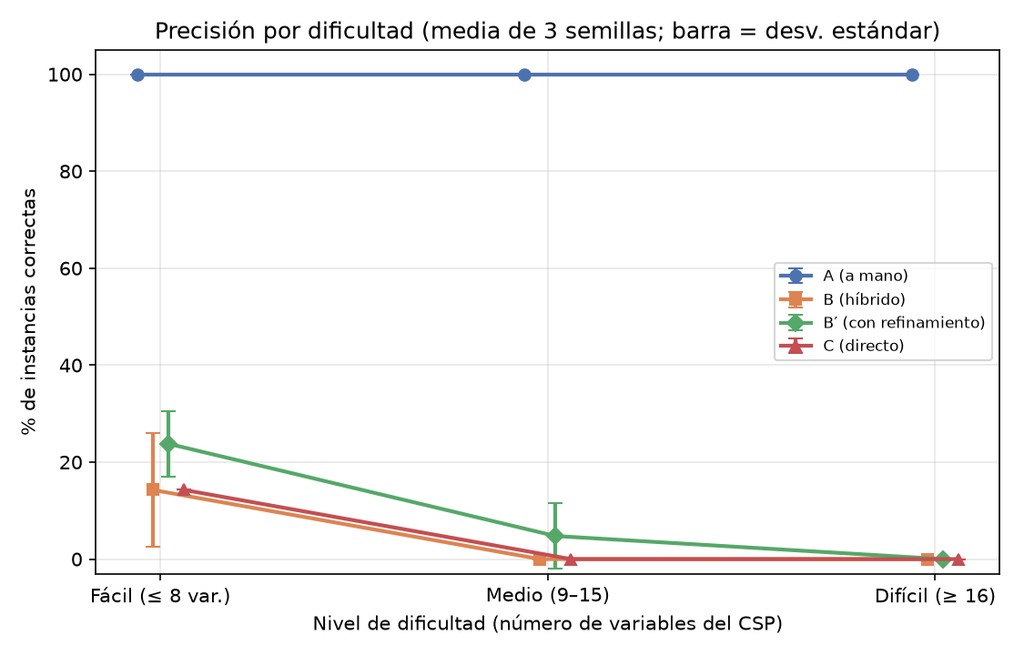

```python
display(Image(filename="fig/precision_vs_dificultad.png"))
```

## 4. Taxonomía de errores del brazo B y la columna que importa: ¿se detecta sin la respuesta correcta?

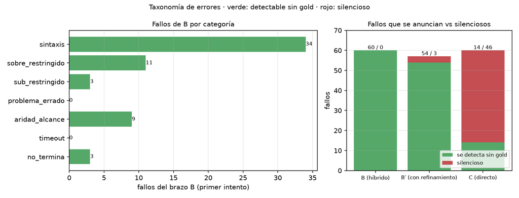

```
B: 60 fallos, 60 detectables sin gold, 0 silenciosos
C: 60 fallos, 14 detectables sin gold, 46 silenciosos
```

```python
display(Image(filename="fig/taxonomia_b.png"))
for brazo in ("B", "C"):
    fallos = [f for f in filas if f["brazo"] == brazo and f["resultado"] != "correcto"]
    det = sum(f["detectable"] == "si" for f in fallos)
    print(f"{brazo}: {len(fallos)} fallos, {det} detectables sin gold, {len(fallos) - det} silenciosos")
```

### Ejemplos verbatim de salidas del modelo (brazo B)

```python
intentos = [json.loads(l) for l in open("results/intentos_b.jsonl", encoding="utf-8")]
vistos = set()
for it in intentos:
    if it["iteracion"] == 1 and it["categoria"] and it["categoria"] not in vistos:
        vistos.add(it["categoria"])
        print(f"--- {it['problema_id']} semilla {it['semilla']} · {it['categoria']}")
        print("solver:", it["mensaje_solver"] or "(solución única)")
        print(it["salida"][:700], "\n")
```

```
--- facil-01 semilla 2 · sobre_restringido
solver: The solver proved the model has NO solution: some constraint is wrong or too strong. Removing any ONE of these constraints would make it solvable, so check them against the puzzle: {"clue": 1, "type": "eq", "a": "Mateo", "b": "Red"}; {"clue": 5, "type": "offset", "a": "Red", "b": "Yellow", "…
{"variables": {"Mateo": [1, 2, 3], "Sofía": [1, 2, 3], "Lucas": [1, 2, 3], "Red": [1, 2, 3], "Yellow": [1, 2, 3], "Blue": [1, 2, 3]}, "constraints": [{"clue": 0, "type": "alldiff", "vars": ["Mateo", "Sofía", "Lucas"]}, {"clue": 0, "type": "alldiff", "vars": ["Red", "Yellow", "Blue"]}, {"clue": 1, "t…

--- facil-02 semilla 0 · sintaxis
solver: Your output could not be parsed: the JSON is incomplete: a closing brace '}' is missing at the end.
{"variables": {"Interview": [1, 2, 3, 4, 5, 6], "Jingle": [1, 2, 3, 4, 5, 6], "News": [1, 2, 3, 4, 5, 6], "Quiz": [1, 2, 3, 4, 5, 6], "Traffic": [1, 2, 3, 4, 5, 6], "Weather": [1, 2, 3, 4, 5, 6]}, "constraints": [{"clue": 0, "type": "alldiff", "vars": ["Interview", "Jingle", "News", "Quiz", "Traffic…

--- facil-03 semilla 2 · aridad_alcance
solver: The solver rejected the model: constraint #3 (offset) compares numbers but 'Ford' has non-numeric values.
{"variables": {"Rim": ["red", "green", "blue"], "Ford": ["red", "green", "blue"], "Gorge": ["red", "green", "blue"], "Dune": ["red", "green", "blue"], "Marsh": ["red", "green", "blue"], "Cliff": ["red", "green", "blue"]}, "constraints": [{"clue": 0, "type": "alldiff", "vars": ["Rim", "Ford", "Gorge"…

--- medio-05 semilla 0 · sub_restringido
solver: The model has MORE THAN ONE solution, so some clue is missing or too weak. Two solutions differ in: Inventory, Lock, Log, Report, Wash, Wipe.
{"variables": {"Blend": [1, 2, 3, 4, 5, 6, 7, 8, 9, 10, 11, 12, 13, 14, 15], "Boil": [1, 2, 3, 4, 5, 6, 7, 8, 9, 10, 11, 12, 13, 14, 15], "Chill": [1, 2, 3, 4, 5, 6, 7, 8, 9, 10, 11, 12, 13, 14, 15], "Chop": [1, 2, 3, 4, 5, 6, 7, 8, 9, 10, 11, 12, 13, 14, 15], "Inventory": [1, 2, 3, 4, 5, 6, 7, 8, 9…

--- dificil-05 semilla 0 · no_termina
solver: LLM: no_termina
```

## 5. Refinamiento: ¿sirve el mensaje del solver como señal de aprendizaje?

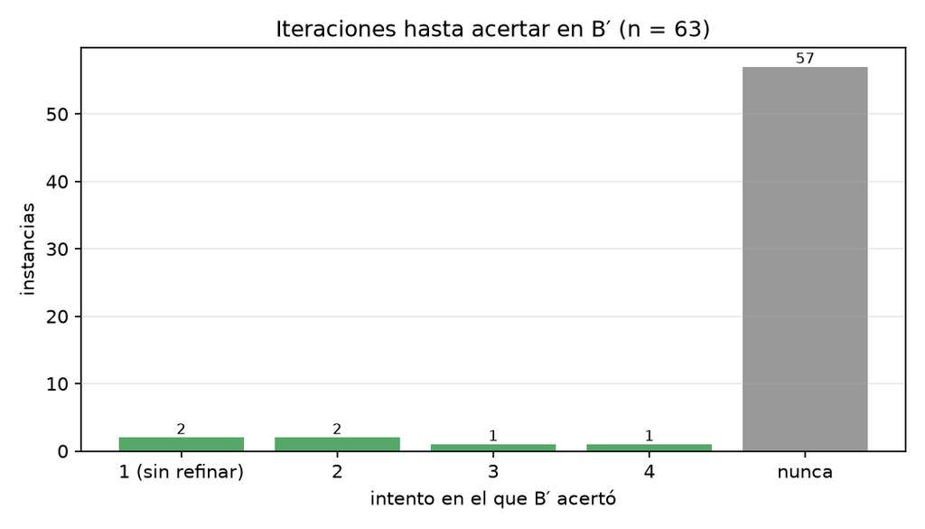

Análisis para el REPORT

Refinamiento (B')

- B: 3/63 (5 %) · B': 6/63 (10 %) · delta = 3 instancias

| Iteraciones hasta acertar | Instancias |
| --- | --- |
| 1 | 2 |
| 2 | 2 |
| 3 | 1 |
| 4 | 1 |
| nunca convergió | 57 |

- Primer error de los que el refinamiento arregló: {'': 1, 'sintaxis': 3}

- Primer error de los que sobrevivieron 3 rondas con un error visible: {'sintaxis': 29, 'aridad_alcance': 9, 'sobre_restringido': 10, 'sub_restringido': 3}

Detectabilidad: B vs C

| Brazo | Fallos | Detectables sin gold | Silenciosos |
| --- | --- | --- | --- |
| B | 60 | 60 | 0 |
| C | 60 | 14 | 46 |

- Errores de C por tipo: {'incorrecta': 46, 'incompleta': 14} (detectable según {'sin_formato': 'si', 'incompleta': 'si', 'incorrecta': 'no', 'no_termina': 'si'})

```python
display(Image(filename="fig/iteraciones_bp.png"))
display(Markdown(open("results/analisis.md", encoding="utf-8").read()))
```

## 6. Costo por respuesta correcta

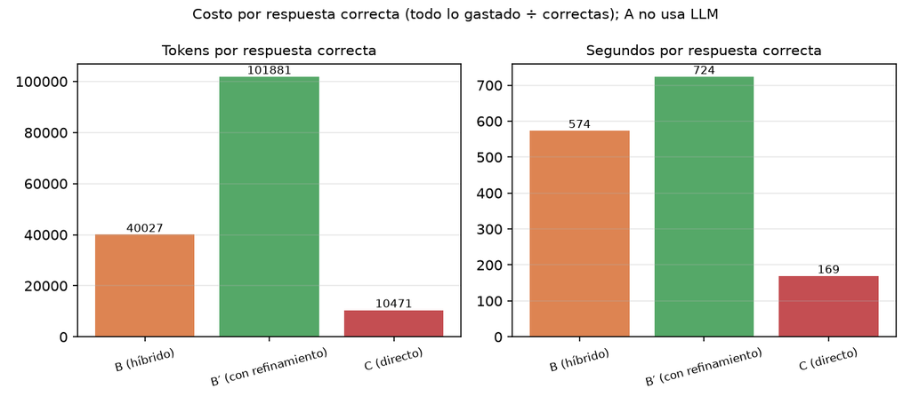

Costo por respuesta correcta

**together** · `Qwen3.5 9B` · $0.17/M entrada, $0.25/M salida · https://www.together.ai/pricing (consultado 2026-11-18)

| Brazo | Intentos | Correctas | Tokens | USD total | USD por correcta | s por correcta |
| --- | --- | --- | --- | --- | --- | --- |
| A | 63 | 63 | 0 | 0.000000 | 0.000000 | 0.0 |
| B | 63 | 3 | 120080 | 0.024529 | 0.008176 | 573.7 |
| Bp | 63 | 6 | 611288 | 0.119932 | 0.019989 | 723.8 |
| C | 63 | 3 | 31414 | 0.005879 | 0.001960 | 169.4 |

```python
display(Image(filename="fig/costo_por_correcta.png"))
display(Markdown(open("results/costos.md", encoding="utf-8").read()))
```

## 7. Dónde se va el tiempo

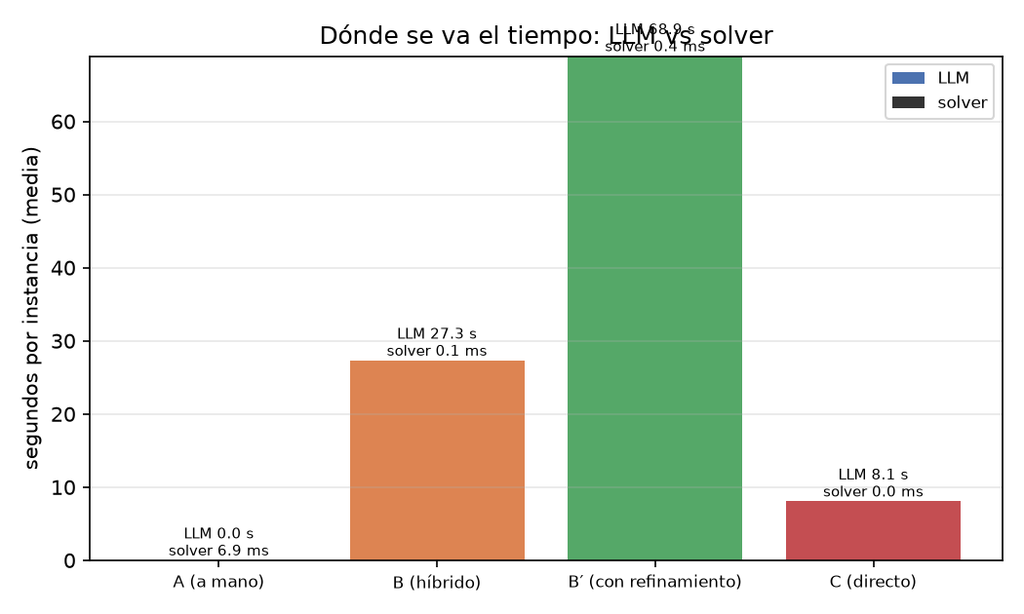

```python
display(Image(filename="fig/tiempo_llm_vs_solver.png"))
```

## 8. Experimento de tamaño: el mismo pipeline con qwen2.5:7b

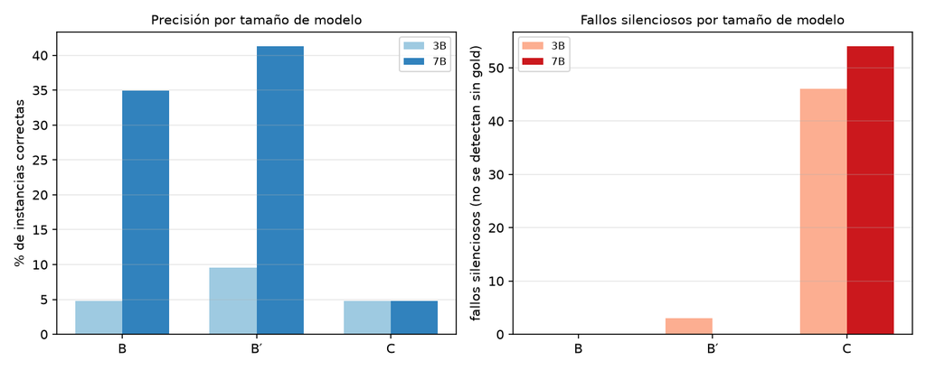

Experimento de tamaño: qwen2.5:3b contra qwen2.5:7b

| Modelo | Brazo | Correctas | Fácil / Medio / Difícil | Fallos | Detectables sin gold | Silenciosos |
| --- | --- | --- | --- | --- | --- | --- |
| 3B | B | 3/63 | 3 / 0 / 0 (de 21 c/u) | 60 | 60 | 0 |
| 3B | B′ | 6/63 | 5 / 1 / 0 (de 21 c/u) | 57 | 54 | 3 |
| 3B | C | 3/63 | 3 / 0 / 0 (de 21 c/u) | 60 | 14 | 46 |
| 7B | B | 22/63 | 13 / 6 / 3 (de 21 c/u) | 41 | 41 | 0 |
| 7B | B′ | 26/63 | 15 / 8 / 3 (de 21 c/u) | 37 | 37 | 0 |
| 7B | C | 3/63 | 3 / 0 / 0 (de 21 c/u) | 60 | 6 | 54 |

- Fallos de B con 3B: {'sobre_restringido': 11, 'sintaxis': 34, 'aridad_alcance': 9, 'sub_restringido': 3, 'no_termina': 3}

- Fallos de B′ con 3B: {'problema_errado': 3, 'sintaxis': 18, 'aridad_alcance': 14, 'sobre_restringido': 15, 'sub_restringido': 4, 'no_termina': 3}

- Fallos de B con 7B: {'sobre_restringido': 21, 'aridad_alcance': 13, 'sub_restringido': 3, 'sintaxis': 1, 'no_termina': 3}

- Fallos de B′ con 7B: {'aridad_alcance': 12, 'sobre_restringido': 20, 'sub_restringido': 2, 'no_termina': 3}

```python
display(Image(filename="fig/modelos.png"))
display(Markdown(open("results/comparacion_modelos.md", encoding="utf-8").read()))
```

## 9. Las pruebas del código pasan

```python
subprocess.run([sys.executable, "code/tests/test_base.py"], check=False)
subprocess.run([sys.executable, "code/tests/test_sin_fugas.py"], check=False)
subprocess.run([sys.executable, "code/verificar_enumeracion.py"], check=False)
```

```
CompletedProcess(args=['C:\\Users\\salaz\\OneDrive\\Documents\\USFQ semestre 7\\IA\\cmp-4004-fall26\\.venv\\Scripts\\python.exe', 'code/verificar_enumeracion.py'], returncode=0)
```

## 10. Conclusión

Con 3B, B y C aciertan lo mismo, pero **todos** los fallos de B se anuncian solos y 46 de 60 de C son silenciosos. Con 7B, B pasa a 22/63 mientras C sigue en 3/63, y B sigue sin fallos silenciosos. La recomendación (B con abstención) y el análisis de dónde pudimos ser injustos están en `REPORT.md`.